# Lab 1A

Data visualization

Mahdi Shafiee Kamalabad and Maarten Cruyff

2026

# Getting Started: Loading the Dataset

Before you begin the practical, you need to load the required dataset into R. To ensure a smooth workflow, please follow one of the two options below:

**Option 1: Using a Dedicated Folder**

Create a specific folder for this assignment and place the dataset file inside it. You can then load the data using the `load()` function by specifying the correct file path. (Note for Windows users: Please ensure you change all backslashes `\` in your copied file path to forward slashes `/` in R).

For **Mac** users, your path will look like this:

```r
load("/Users/your_username/Documents/folder_name/dataset_name.RData")
```

For **Windows** users, your path will look like this:

```r
load("C:/Users/your_username/Documents/folder_name/dataset_name.RData")
```

**Option 2: Using an R Project**

Create an R Project (`.Rproj`) for this assignment and store the dataset directly within that project folder. Make sure to open RStudio by double-clicking the `.Rproj` file. This automatically sets your working directory, allowing you to load the dataset directly without a long path:

```r
load("dataset_name.RData")
```

**Note for this specific lab:** While the above options outline the standard workflow for local files, you do not need to download or load a `.RData` file for this specific lab. Today, we will access our data directly through an R package.

# Collaborating in Data Science

Before starting the lab, please note that **teamwork** is an essential part of **data science**. Real-world data problems are rarely solved alone. Data scientists collaborate to explore data, validate results, and communicate insights effectively. In this course, you are encouraged to work together, discuss ideas, compare visualizations, and help each other understand the concepts. Learning as a team not only strengthens your analytical skills but also reflects how data science is practiced in professional environments.

# Why visualization?

- Turn raw data into something we can see and reason about.
- Reveal patterns, trends, and relationships that are hard to spot in tables.
- Detect outliers, errors, and missing data.
- Support both exploration (understanding the data) and communication (explaining results to others).

# R packages used in this lab

In this course, we use visualization as a first step in almost every data analysis or machine learning task. For this lab you will use the `R` packages `ggplot2`, `palmerpenguins`, and `patchwork`. The `ggplot2` package provides a powerful system for building plots layer by layer, while `palmerpenguins` supplies a convenient real-world dataset for practicing visualization. The `patchwork` package simply allows you to easily combine multiple ggplot2 plots into a single layout. If you load the full ‘tidyverse’ package, it automatically includes `ggplot2`, so you only need to load `ggplot2` separately when you are not using the tidyverse.

# Loading packages and exploring the dataset

1. Load the above packages in workspace.

   **Hint:** Use the `library()` function for each of the three packages mentioned above.

**Show Answer**

```r
library(ggplot2) # ggplot2 is R’s most widely used system for data visualization.
library(palmerpenguins) # Provides clean biological data on penguin species, body size, island, sex, etc.
library(patchwork) # Allows you to combine multiple ggplots into one layout easily (no complicated code).
```

2. The data set is `penguins` from the `palmerpenguins` package.

   **Hint:** The `?` operator is your friend here. Just type it before the dataset name.

**Show Answer**

```r
?penguins  # opens help in RStudio only — not shown in knitted output
```

```
## Help on topic 'penguins' was found in the following packages:
##
##   Package               Library
##   datasets              /Library/Frameworks/R.framework/Versions/4.6/Resources/library
##   palmerpenguins        /Users/shafi004/Library/R/arm64/4.6/library
##
##
## Using the first match ...
```

3. It is always a good idea to look at the data first to understand what it contains and check for any issues. Now, display the first 10 rows using `head()` and show the structure of the dataset using `str()`.

   **Hint:** Pass the dataset name to both functions. Remember that `head()` accepts a second argument to specify the exact number of rows you want to see.

**Show Answer**

```r
head(penguins, 10) # the first 10 rows of the data. Note that  "str(penguins)" shows the structure of the data and the types of the variables
```

| species | island | bill_length_mm | bill_depth_mm | flipper_length_mm | body_mass_g | sex | year |
| --- | --- | --- | --- | --- | --- | --- | --- |
| Adelie | Torgersen | 39.1 | 18.7 | 181 | 3750 | male | 2007 |
| Adelie | Torgersen | 39.5 | 17.4 | 186 | 3800 | female | 2007 |
| Adelie | Torgersen | 40.3 | 18.0 | 195 | 3250 | female | 2007 |
| Adelie | Torgersen | NA | NA | NA | NA | NA | 2007 |
| Adelie | Torgersen | 36.7 | 19.3 | 193 | 3450 | female | 2007 |
| Adelie | Torgersen | 39.3 | 20.6 | 190 | 3650 | male | 2007 |
| Adelie | Torgersen | 38.9 | 17.8 | 181 | 3625 | female | 2007 |
| Adelie | Torgersen | 39.2 | 19.6 | 195 | 4675 | male | 2007 |
| Adelie | Torgersen | 34.1 | 18.1 | 193 | 3475 | NA | 2007 |
| Adelie | Torgersen | 42.0 | 20.2 | 190 | 4250 | NA | 2007 |

As you can see the penguins dataset includes measurements for three penguin species in the Palmer Archipelago, Antarctica. See below for a brief codebook.

| Variable | Description |
| --- | --- |
| **species** | Penguin species (*Adélie*, *Chinstrap*, *Gentoo*) |
| **island** | Island where each penguin was observed (*Biscoe*, *Dream*, *Torgersen*) |
| **bill_length_mm** | Bill length (mm),a measure of how long the beak is |
| **bill_depth_mm** | Bill depth (mm), a measure of how tall/thick the beak is |
| **flipper_length_mm** | Flipper length (mm), related to swimming ability |
| **body_mass_g** | Body mass (g), an indicator of penguin size |
| **sex** | Sex of the penguin (*male*, *female*, or missing) |
| **year** | Observation year (2007–2009) |

See here for more information about this dataset https://allisonhorst.github.io/palmerpenguins/

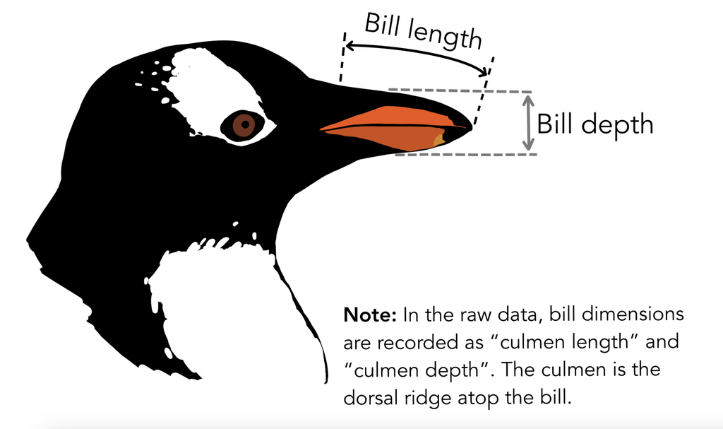

Some measurements for 11 penguins in the dataset are **missing**. These missing values can generate warnings when plotting or analyzing the data. Missing data occurs when certain observations have no recorded value for one or more variables. This can influence the results of an analysis, so it is important to recognize and handle missing values appropriately.

4. To avoid these warnings, create a new dataset called `peng` that removes all rows containing missing values.**Note**: Removing missing cases with `na.omit()` is simple, but it is not always the best approach. Deleting rows reduces the size of your dataset and may introduce bias if the missing values are not random or many observations are removed. In practice, analysts often explore why data are missing or use methods such as **imputation** rather than removing entire observations.

   **Hint:** Apply the `na.omit()` function to the `penguins` dataset and assign the result to a new object named `peng` using the `<-` operator.

**Show Answer**

```r
peng <- na.omit(penguins)
```

# Geoms

We start by exploring the most common geoms for categorical and numeric variables, and combinations thereof.

For quick help on `ggplot2` functions, see [ggplot2 reference](https://ggplot2.tidyverse.org/reference)

A numeric variable can be continuous (like bill length or body mass) or discrete (like counts). In this lab, our numeric variables happen to be continuous, which is why histograms and density plots are appropriate. Discrete numeric variables such as counts of events are technically numeric but are usually visualized differently (e.g., bar plots).

1. Display a histogram and a density plot of the variable `body_mass_g` next to each other using the `|` or `+` operator from the patchwork package. Limit the number of bins in each histogram to 15 (bins = 15). To improve the proportions of the plots, use the chunk option `fig.asp = .4`. The chunk option fig.asp = .4 controls the aspect ratio of the figure. A smaller aspect ratio makes the plot wider relative to its height, which is often helpful when placing multiple plots side by side.

   **Hint:** Create two separate ggplot objects (e.g., `p1` and `p2`). For the first, use `geom_histogram(bins = 15)`. For the second, use `geom_density()`. Finally, combine them by writing `p1 | p2`.

**Show Answer**

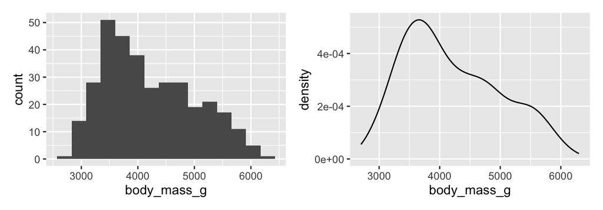

```r
p1 <- ggplot(peng, aes(body_mass_g)) +
  geom_histogram(bins = 15)

p2 <- ggplot(peng, aes(body_mass_g)) +
  geom_density()
p1 | p2 # or p1 + p2
```

```r
# You do not need to assign each plot to an object (like p1, p2) when using patchwork. You can combine multiple ggplot() calls directly with + or |
```

A categorical variable is usually visualized with a bar plot, which shows the number of observations in each category and makes it easy to compare group sizes.

2. Create a bar plot showing the counts of each `species`. Next to it, create the same bar plot, but with the bars filled according to the variable `island` so you can see how each species is distributed across islands.

   **Hint:** The geom for a bar plot is `geom_bar()`. For the second plot, map the `island` variable to the `fill` aesthetic inside the `aes()` function.

**Show Answer**

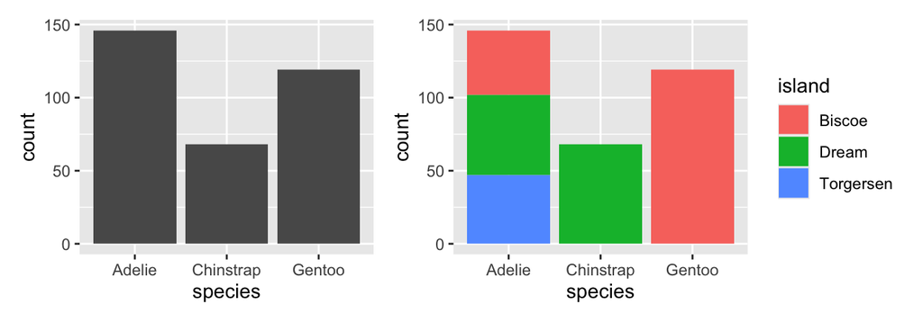

```r
p1 <- ggplot(peng, aes(species)) +
  geom_bar()

p2 <- ggplot(peng, aes(species, fill = island)) +
  geom_bar()

p1 | p2
```

3. An alternative for plotting two categorical variables is `geom_count()`, which displays the number of observations for each combination of categories. Plot the variables species and year (treating year as a factor) using this geom.

   **Hint:** Inside `aes()`, map `factor(year)` to the x-axis and `species` to the y-axis, then add the `geom_count()` layer.

**Show Answer**

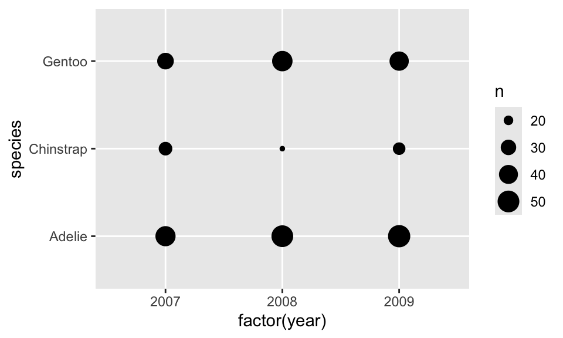

```r
ggplot(peng, aes(factor(year), species)) +
  geom_count()
```

The combination of a numeric and a categorical variable is commonly visualized with box plots, violin plots, or density plots. These plots make it easy to compare the distribution of a numeric variable across different categories (e.g. you are interested in how the numeric values differ across the categories.).

4. Create three different visualizations to compare the distribution of `body_mass_g` across the penguin species. Produce the following plots: i) A box plot of body_mass_g by species. ii) A violin plot of body_mass_g by species. iii) A density plot of body_mass_g, with densities filled by species.

   **Hint:** For the boxplot and violin plot, `species` goes on the x-axis and `body_mass_g` on the y-axis. For the density plot, map `body_mass_g` to the x-axis and map `species` to the `fill` aesthetic. Use patchwork (`|`) to place them side by side.

**Show Answer**

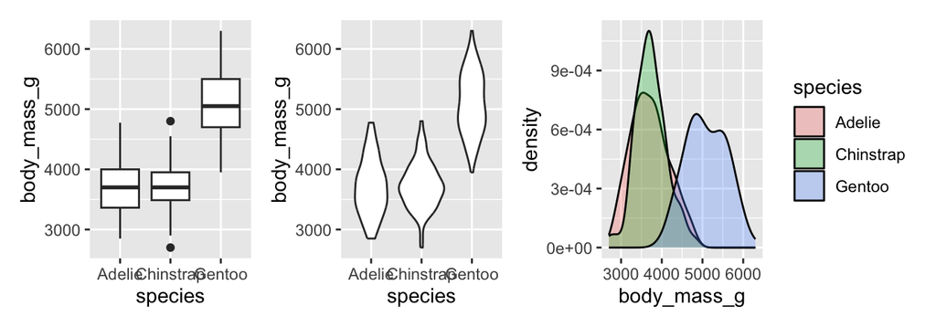

```r
p1 <- ggplot(peng, aes(species, body_mass_g)) +
  geom_boxplot()

p2 <- ggplot(peng, aes(species, body_mass_g)) +
  geom_violin()

p3 <- ggplot(peng, aes(body_mass_g, fill = species)) +
  geom_density(alpha = .3)

p1 | p2 | p3
```

Two numeric (continuous) variables can also be visualized with a scatter plot, which shows how one variable changes in relation to the other and can reveal patterns such as trends, clusters, or outliers.

5. Display a scatter plot with bill length on the x-axis and bill depth on the y-axis.

   **Hint:** The geometric layer used for creating scatter plots is `geom_point()`.

**Show Answer**

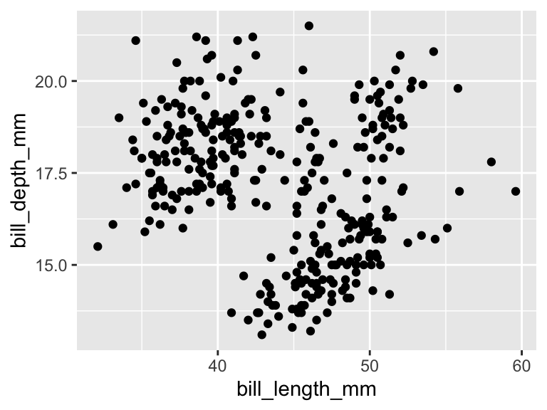

```r
ggplot(peng, aes(bill_length_mm, bill_depth_mm)) +
  geom_point()
```

6. Since this scatter plot will be used in the next exercises, save it under the name p. Add the title “Penguin bill dimensions” and change the axis labels to “length” and “depth” using the `labs()` layer.

   **Hint:** Use `p <- ggplot(...) + labs(...)`.

**Show Answer**

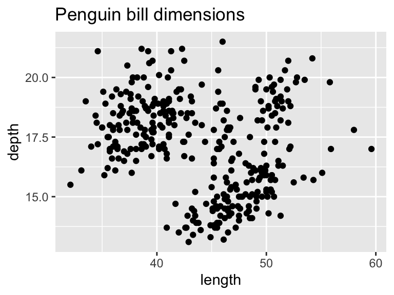

```r
p <- ggplot(peng, aes(bill_length_mm, bill_depth_mm)) +
  geom_point() +
  labs(title = "Penguin bill dimensions",
       x = "length",
       y = "depth")
p
```

7. Further improve the scatter plot by coloring the points according to species using `aes(color = species)`, adjusting the transparency with `alpha` to reduce overplotting, or modifying the point size for better visibility.

   **Hint:** Fixed settings like `alpha` and `size` go directly inside `geom_point()`. Since color depends on the data variable (`species`), it must be mapped inside `aes()`: e.g., `aes(color = species)`.

**Show Answer**

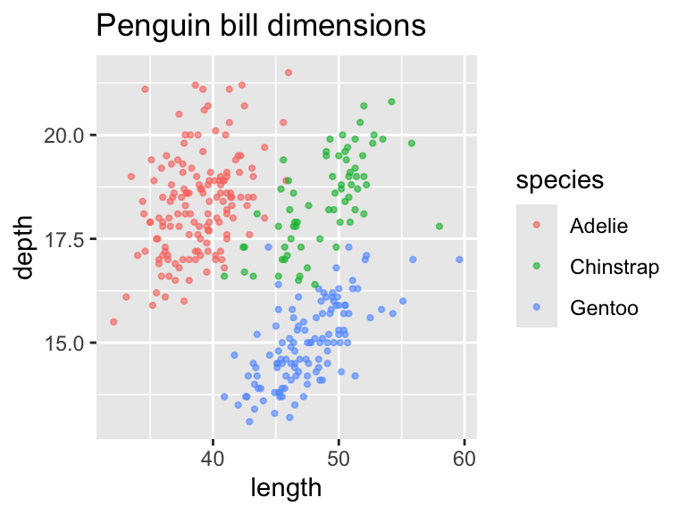

```r
ggplot(peng, aes(bill_length_mm, bill_depth_mm, col = species)) +
  geom_point(alpha = 0.6, size = .8) +    #play around with the value of size
  labs(title = "Penguin bill dimensions",
       x = "length",
       y = "depth")
```

# Adding layers

Adding layers changes the appearance of the plot. We’ll try out a few of them to see how additional geoms or settings can highlight different aspects of the data.

## Regression lines

A regression line is a line that summarizes the relationship between variables by showing the general trend in the data. We will discuss regression models in more detail later in the course. Scatter plots are often accompanied by regression lines. The geom for this is `geom_smooth()`, which, as the name suggests, adds a smooth regression line to the plot. By default, `geom_smooth()` fits a **nonlinear** smooth curve (a smooth, possibly curved line) and displays a confidence band around it. A **linear** regression line is obtained by specifying `method = "lm"`, and the confidence bands can be removed by setting `se = FALSE`.

1. Using the scatter plot saved as `p` from the previous exercises, display side by side a version of `p` with a smooth (nonlinear) regression line and confidence band, and a version of `p` with a linear regression line without a confidence band. As before, the `patchwork` package helps us to place the two plots next to each other.

   **Hint:** `geom_smooth()` creates a nonlinear curve by default. To make it linear and remove the confidence band, use the arguments `method = "lm"` and `se = FALSE`.

**Show Answer**

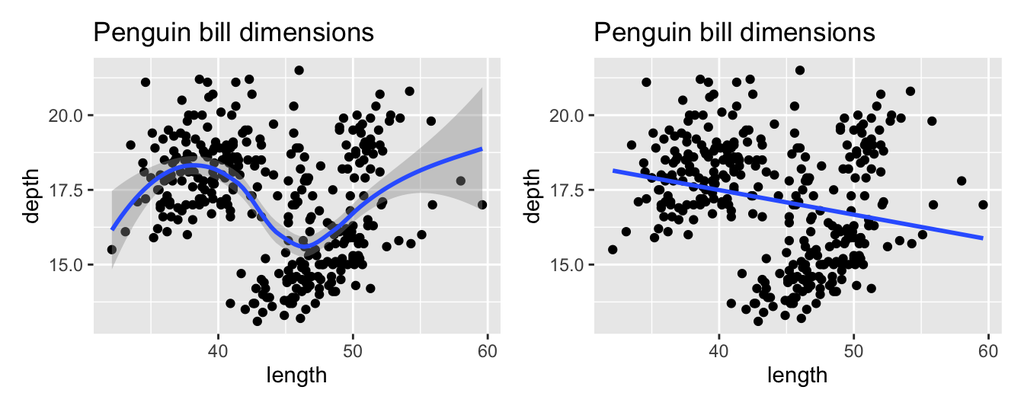

```r
(p + geom_smooth()) | (p + geom_smooth(method = "lm", se = FALSE))
```

By redefining the `geom_point()` layer with the aesthetic `col = species`, the scatter plot from the previous exercise now shows points in different colors for each species. The same applies to the regression lines: adding `col = species` inside the `geom_smooth()` layer produces separate, differently colored regression lines for each species.

2. Plot `p` with the points colored by the levels of `species` and next to it the same plot with linear regression lines colored by `species`. At the end, add a layer `plot_layout(guides = 'collect')` to have the legends displayed at the right of the plots.

   **Hint:** You can add `aes(col = species)` locally inside the `geom_point()` and `geom_smooth()` layers. Combine the two plots using the `|` operator before adding the `plot_layout` layer.

**Show Answer**

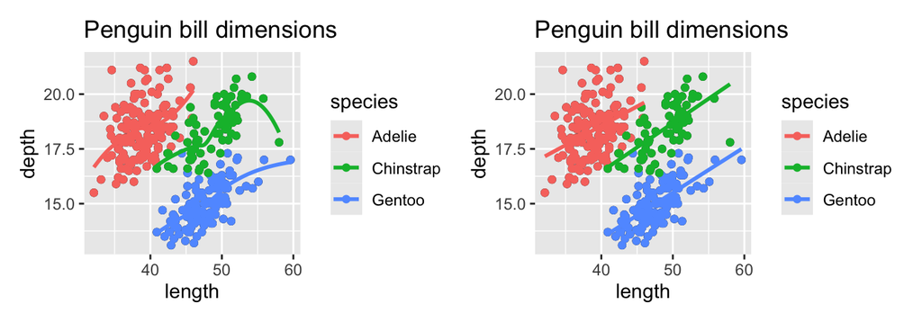

```r
(p + geom_point(aes(col = species)) + geom_smooth(aes(col = species), se = FALSE)) |
(p + geom_point(aes(col = species)) + geom_smooth(aes(col = species), method = "lm", se = FALSE)) +
  plot_layout(guides='collect')
```

Try adding `col = species` to different geoms and remove form others above and compare how coloring affects the plot.

As we can see by comparing the last two exercises, the apparent relationship between the bill dimensions reverses once we account for (control for) the penguin species. This becomes clear in the **linear** regression results.

This is an example of Simpson’s paradox: a trend that appears in the overall data disappears or reverses when the data are divided into meaningful subgroups. [Simpson’s paradox](https://en.wikipedia.org/wiki/Simpson%27s_paradox).

3. Display a plot with `flipper_length_mm` on the x-axis, `body_mass_g` on the y-axis, with different colors and linear regression lines for `species`, and give points for the levels of `sex` a different `shape`.

   **Hint:** Set the global aesthetics for x, y, and color in the main `ggplot()` function. Then, map `sex` to the `shape` aesthetic specifically inside the `geom_point()` layer.

**Show Answer**

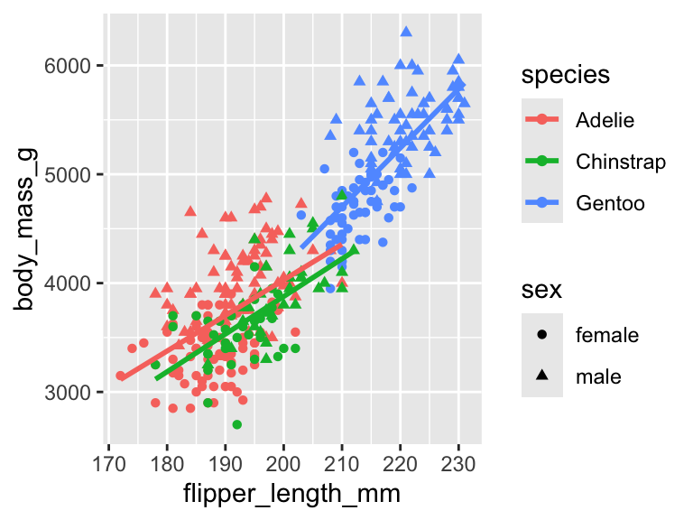

```r
ggplot(peng, aes(flipper_length_mm, body_mass_g, col = species))  +
  geom_point(aes(shape = sex)) +
  geom_smooth(method = "lm", se = FALSE)
```

4. `geom_density_2d()` adds contour lines that represent areas of higher and lower point density in a scatter plot. These contours help reveal underlying structure, such as clusters or regions where observations are more concentrated.

   Starting from the scatter plot of `bill_length_mm` (x-axis) and `bill_depth_mm` (y-axis), add 2D density contours using `geom_density_2d()`. Then create a second version where the points are colored by species, and the density contours are also drawn separately for each species.

   **Hint:** For the second version of the plot, ensure `color = species` is mapped inside the main `aes()` so that both the points and the contours are colored by species.

**Show Answer**

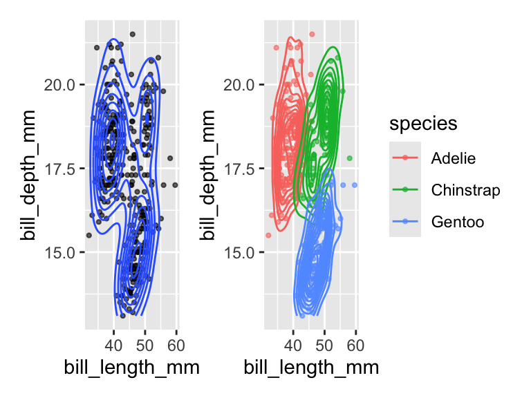

```r
ggplot(peng, aes(bill_length_mm, bill_depth_mm)) +
  geom_point(alpha = 0.6, size = 0.8) +
  geom_density_2d() +
ggplot(peng, aes(bill_length_mm, bill_depth_mm, color = species)) +
  geom_point(alpha = 0.6, size = 0.8) +
  geom_density_2d()
```

# Facets

As you have seen, some of the previous plots looked a bit crowded when all species were shown together. In such cases, it can be very helpful to create multiple small plots using `facet_grid()` or `facet_wrap()`. Faceting separates the data into panels based on one or more **categorical** variables, sometimes making patterns really easier to see and allowing for clearer comparisons between groups. `facet_wrap()` creates a series of plots wrapped into one or more rows, which is useful when faceting by usually a single variable. `facet_grid()` arranges panels in a grid defined by usually two variables (rows and columns), which allows you to compare categories along two dimensions.

1. Remove `sex` from the aesthetics of the previous plot, and instead use it as the aesthetic in `facet_wrap()`. Remember that the argument of this function requires `vars(<variable>)`.

   **Hint:** Simply add `+ facet_wrap(vars(sex))` to the end of your ggplot code chain.

**Show Answer**

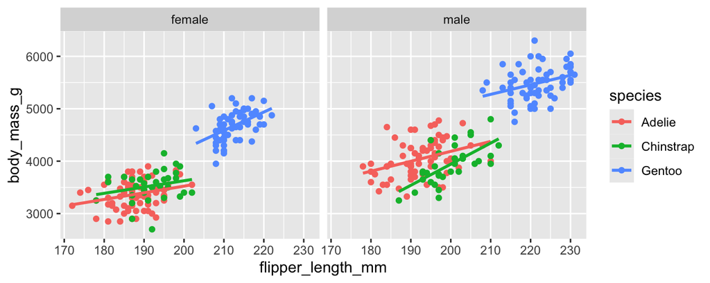

```r
ggplot(peng, aes(flipper_length_mm, body_mass_g, col = species))  +
  geom_point() +
  geom_smooth(method = "lm", se = FALSE)  +
  facet_wrap(vars(sex))
```

2. Create the same plot, but now add separate panels for each `island`, placing the islands in the columns.

   **Hint:** Use `facet_grid()`. Set the `rows` argument to `vars(sex)` and the `cols` argument to `vars(island)`.

**Show Answer**

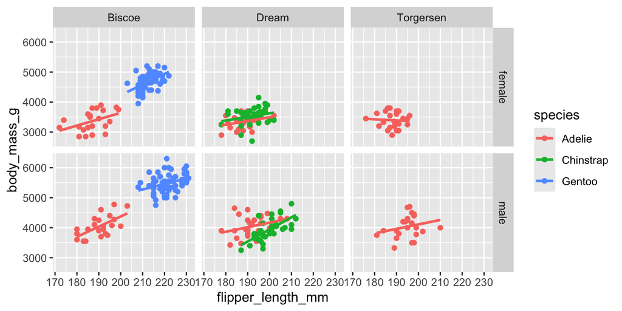

```r
ggplot(peng, aes(flipper_length_mm, body_mass_g))  +
  geom_point(aes(col = species)) +
  geom_smooth(aes(col = species), method = "lm", se = FALSE)  +
  facet_grid(rows = vars(sex), cols = vars(island))
```

# Themes

There are multiple plot themes you can choose from in `ggplot2`, each providing a different overall appearance for your plots. Themes control elements such as background color, grid lines, fonts, and borders, allowing you to tailor the look of your visualization to your needs whether for exploration, publication, or presentation.

1. Using the plot `p` from the previous exercise, display it with three different themes in a 3 × 1 plot layout. Use the `patchwork` package as before to arrange the three versions of `p` in a single column, and add the layer `plot_layout(axes = "collect") & ggtitle(NULL)` to collect the axis labels and remove the individual plot titles.

   **Hint:** Add a different theme function (like `+ theme_minimal()`) to each `p`. Stack them vertically using the `/` operator.

**Show Answer**

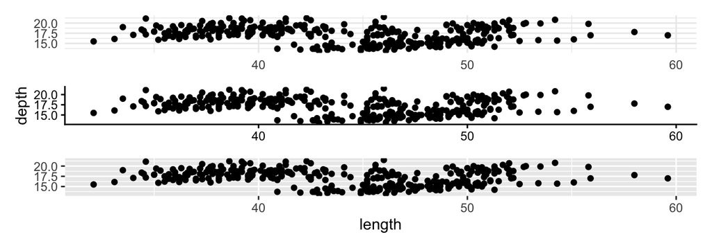

```r
(p + theme_minimal()) /
(p + theme_classic()) /
(p + theme_grey()) +
  plot_layout(axes = "collect") & ggtitle(NULL) # add ncol = 1, and see what happens
```

# Advanced exercises

A histogram is sometimes combined with a density plot to show both the frequency of observations and the overall distribution shape in a single figure. However, these two `geoms` use different y-scales by default: histograms show counts (or sometimes proportions), while density plots show densities that integrate to 1. To overlay them correctly, both geoms must use the **same** scale on the y-axis. This can be achieved by using the `after_stat()` function, which allows you to transform the computed statistic of a geom; for example, using `after_stat(density)` inside the histogram layer so that both the histogram and the density curve display density values on a comparable scale.

1. Display the combined histogram and density plot. To make the histogram look nicer, set the histogram border color to black and the fill color to white, and color the density line red.

   **Hint:** Define `col = "black"` and `fill = "white"` directly inside `geom_histogram()` (outside of the `aes()` function, because these are fixed colors, not mapped to data).

**Show Answer**

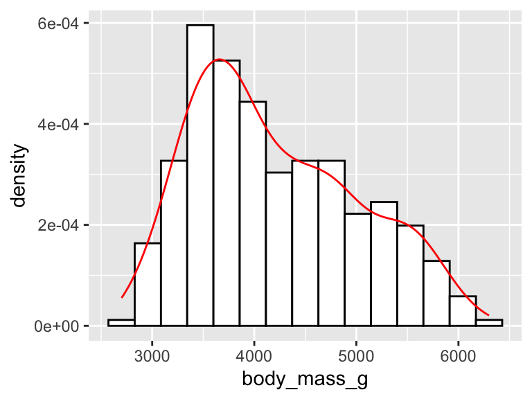

```r
ggplot(peng, aes(body_mass_g)) +
  geom_histogram(aes(y = after_stat(density)),
                 bins = 15,
                 col = "black",
                 fill = "white") +
  geom_density(col = "red")
```

2. Create a plot that compares the distribution of `body_mass_g` across both `species` and `sex` by combining a histogram and a density plot. Use a histogram of `body_mass_g` with `after_stat(density)` so it is on the same `y-scale` as a density curve, overlay a density line in each panel, and facet the plot with `facet_grid(sex ~ species)` so that rows correspond to `sex` and columns correspond to `species`. Make the histogram visually clear by using a white fill and black outline, and choose a contrasting color for the density curve. Use this plot to observe how body mass distributions differ across the species–sex combinations.

   **Hint:** Build upon your code from exercise ‘a’. Add the `facet_grid()` layer and use the `rows` and `cols` arguments with `vars(sex)` and `vars(species)`.

**Show Answer**

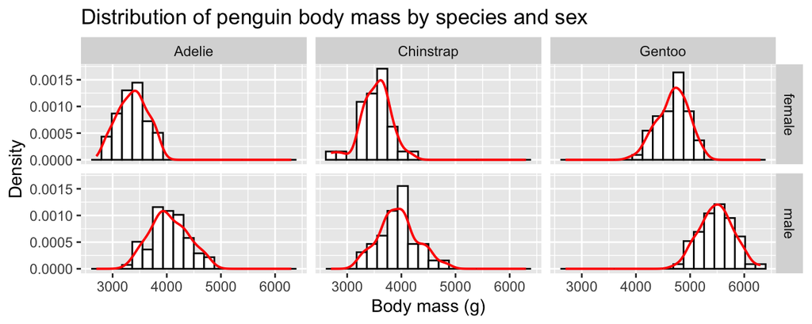

```r
ggplot(peng, aes(body_mass_g)) +
  geom_histogram(
    aes(y = after_stat(density)),
    bins = 20,
    col = "black",
    fill = "white"
  ) +
  geom_density(col = "red", linewidth = 0.7) +
  facet_grid(rows = vars(sex), cols = vars(species)) +
  labs(
    x = "Body mass (g)",
    y = "Density",
    title = "Distribution of penguin body mass by species and sex"
  )
```

3. Provide a brief summary of what you have learned in this lab.

# Final advice

As you continue working with data visualization, remember that the goal is not just to produce plots, but to understand your data and communicate your findings clearly. Always start by exploring your dataset, checking variable types, looking for missing values, and creating simple visual summaries. Practice layering geoms, adjusting aesthetics, and experimenting with themes. Note that small changes can often reveal important patterns. Use faceting and color wisely to clarify, not clutter. Most importantly, stay curious and take time to reflect on what each visualization tells you. With consistent practice, these skills will become a natural and powerful part of your data science workflow.

END OF LAB.